# Two-Way ANOVA Using R

Etana Disasa

6/11/2019

# Introduction

For this assignment, we will utilize the dataframe `MyData` from its source file `engineer.csv`. For this purpose of this work, the file was downloaded from https://raw.githubusercontent.com/ywchiu/rcookbook/master/chapter5/engineer.csv. The data shows observations that show the salaries of several professionals in the BI Engineers, Data Scientists and Software Engineers from the New York, San Francisco and Seattle regions. The purpose of this assignment is to fingure out if there is interaction between the profession of these professionals and the region they work from that is predictive of their salaries. In order to achieve this, we will first try to understand what the data set is, explore the data and perform a two-way ANOVA test to make the determination. Furthermore, we will do some diagnosis to see if the model we used for these tests were good models.

### Data Aquiring

```r
MyData <- read.csv("engineer.csv", header = TRUE)
str(MyData)
```

```
## 'data.frame':    180 obs. of  4 variables:
##  $ X         : int  1 2 3 4 5 6 7 8 9 10 ...
##  $ Salary    : int  126411 108402 99399 91381 105023 108944 123952 108217 103722 140179 ...
##  $ Profession: Factor w/ 3 levels "BI Engineer",..: 2 2 2 2 2 2 2 2 2 2 ...
##  $ Region    : Factor w/ 3 levels "New York","San Francisco",..: 2 2 2 2 2 2 2 2 2 2 ...
```

The above code reads `engineer.csv` as `MyData`. MyData is a data frame that has 4 variables and a total of 180 observations. The two variables we will be using as independant variable will be `Profession` and `Region` which are factors with three levels. `Salary` is the dependant variable in this process.

### Data Exploration

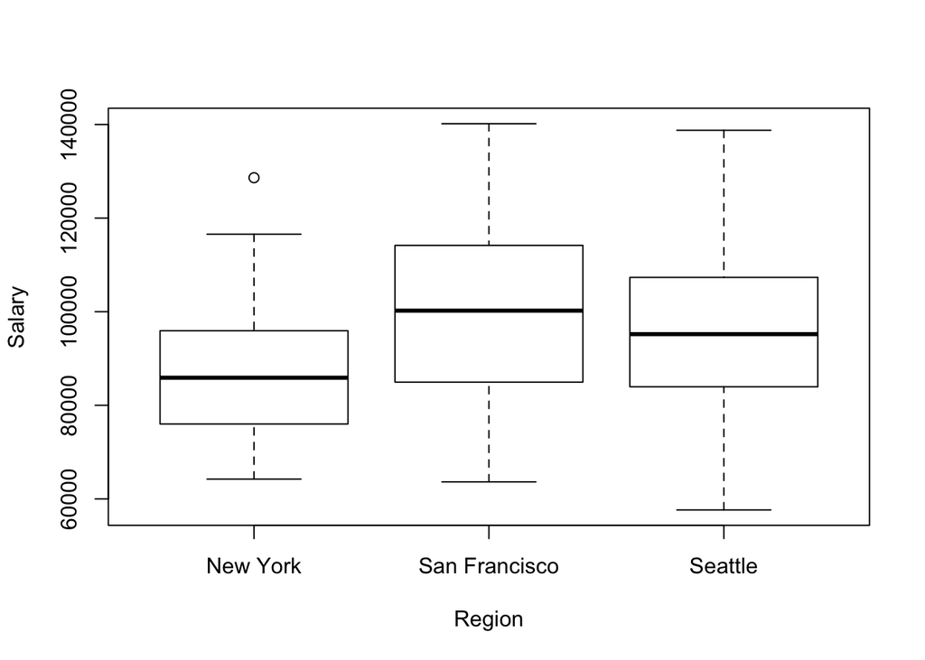

```r
plot(Salary ~  Region, data = MyData)
```

The above plot indicates that San Francisco has the highest median Salary across the board. Next to that is Seattle followed by New York. This plot does not identify which profession pays more or otherwise which will be discussed in the next plot.

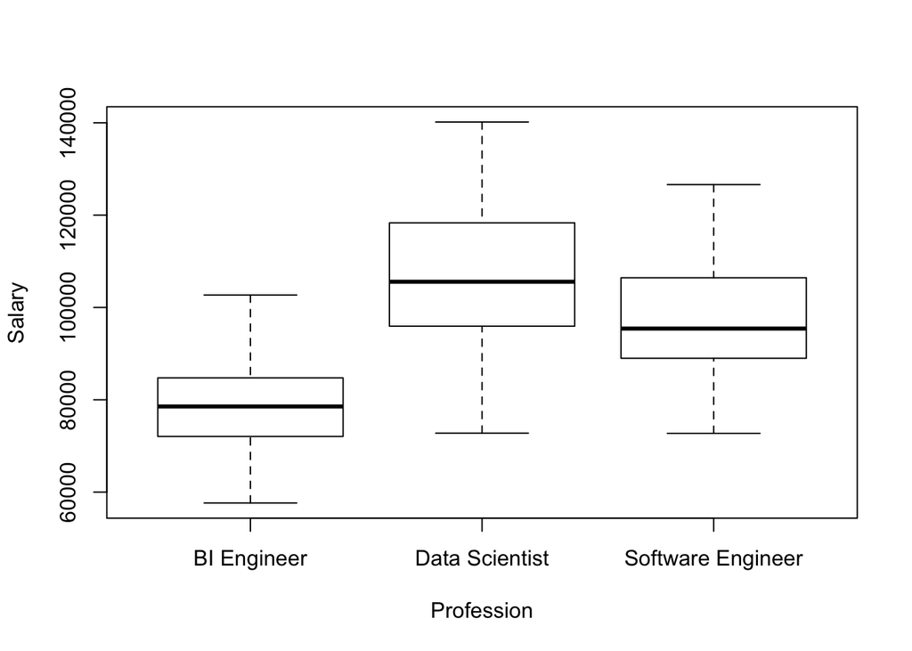

```r
plot(Salary ~  Profession, data = MyData)
```

Here, this plot displays that, across the three regions, the median salary for Data Scientist is the highest ((;Yeay!!). Software Engineers follow on with a median salary below $100,000. Then follows, BI Engineers with a median salary slightly under the $80,000 mark. But still, these two plots do not help us understand interactions between these two variables, Salary and Region.

### Hypothesis Formulation

Here, what we are trying to find out is whether the interation of one factor on the dependant variable depends on the level of the other factor. In this case, given MyData, we will try to see if the interaction of Profession on the Salary of an individual depends on the Region where the individual is located. Therefore, our hypothesis will be:

**H<sub>0</sub>: There is no statistically significant interaction between Profession and Region.**

**H<sub>1</sub>: There is a statistically significant interaction between Profession and Region.**

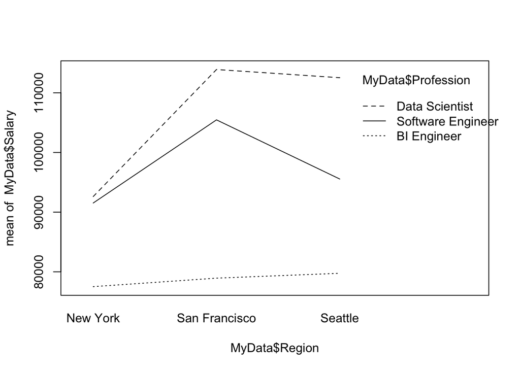

```r
interaction.plot(MyData$Region, MyData$Profession, MyData$Salary)
```

The interaction plot above displays that individuals working as BI Engineer, Data Scinetis and Software Engineer in New York appear to be making less annually than their counterparts in San Francisco and Seattle. Furthermore, Software Engineers and Data Scientists make more in San Francisco than Seattle. However, BI Engineers make more in Seattle than New York and San Francisco. If the lines were parallel, one may suggest that there is no interaction. Nevertheless, the plot suggest that there may be interaction. Just looking at this plot, determining whether there is interaction between Region and Profession would not allow for an objective and emperical conclusion. Thus, performing a two-way ANOVA test will be necessary.

### Two-Way ANOVA Test

```r
My_Salary_Model <- lm(Salary ~ Region*Profession, MyData)
summary(My_Salary_Model)
```

```
##
## Call:
## lm(formula = Salary ~ Region * Profession, data = MyData)
##
## Residuals:
##    Min     1Q Median     3Q    Max
## -23776  -8369  -1215   7426  36023
##
## Coefficients:
##                                                 Estimate Std. Error
## (Intercept)                                        77519       2632
## RegionSan Francisco                                 1421       3722
## RegionSeattle                                       2236       3722
## ProfessionData Scientist                           15093       3722
## ProfessionSoftware Engineer                        14011       3722
## RegionSan Francisco:ProfessionData Scientist       19866       5264
## RegionSeattle:ProfessionData Scientist             17680       5264
## RegionSan Francisco:ProfessionSoftware Engineer    12514       5264
## RegionSeattle:ProfessionSoftware Engineer           1783       5264
##                                                 t value Pr(>|t|)
## (Intercept)                                      29.454  < 2e-16 ***
## RegionSan Francisco                               0.382 0.703029
## RegionSeattle                                     0.601 0.548786
## ProfessionData Scientist                          4.055 7.61e-05 ***
## ProfessionSoftware Engineer                       3.764 0.000229 ***
## RegionSan Francisco:ProfessionData Scientist      3.774 0.000221 ***
## RegionSeattle:ProfessionData Scientist            3.359 0.000965 ***
## RegionSan Francisco:ProfessionSoftware Engineer   2.377 0.018538 *
## RegionSeattle:ProfessionSoftware Engineer         0.339 0.735213
## ---
## Signif. codes:  0 '***' 0.001 '**' 0.01 '*' 0.05 '.' 0.1 ' ' 1
##
## Residual standard error: 11770 on 171 degrees of freedom
## Multiple R-squared:  0.5719, Adjusted R-squared:  0.5518
## F-statistic: 28.55 on 8 and 171 DF,  p-value: < 2.2e-16
```

```r
anova(My_Salary_Model)
```

|  | Df | Sum Sq | Mean Sq | F value | Pr(>F) |
| --- | --- | --- | --- | --- | --- |
| Region | 2 | 4749900534 | 2374950267 | 17.143260 | 1.638138e-07 |
| Profession | 2 | 23855130983 | 11927565492 | 86.097532 | 1.356467e-26 |
| Region:Profession | 4 | 3037177895 | 759294474 | 5.480865 | 3.554522e-04 |
| Residuals | 171 | 23689572207 | 138535510 | NA | NA |

Accordingly, the Region-Profession interaction has a p-value of 0.0003555, which is less than our signicance level of 0.05. As a result, we reject the null-hypothesis. There is a statistically significant interaction between `Profession` and `Region`.

### Diagnostic Tests

For the diagnostic test, I was going to use the qqnorm plot as below.

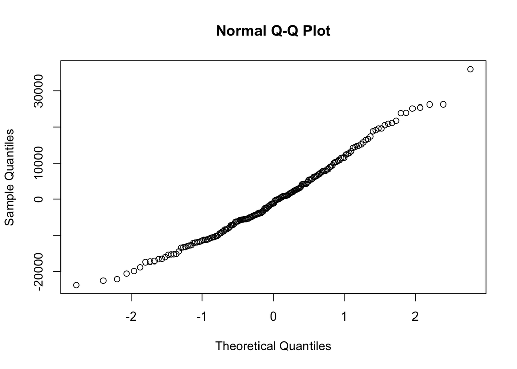

```r
qqnorm(My_Salary_Model$residuals)
```

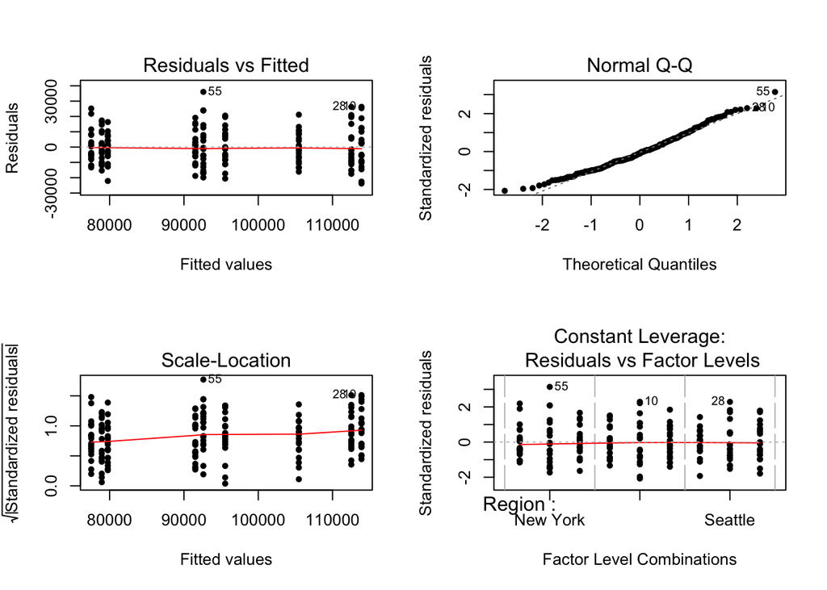

```r
par (mfrow=c(2,2))
plot(My_Salary_Model, pch = 20)
```

##### 1. Residuals vs Fitted Plot

This plot displays if the residuals have non-linear patterns. If there is a non-linear relationship between the predictor variable and the outcome variable, and the model did not capture it; then that pattern could show up here in this plot. In other words, if the model did a good job of capturing such non-linear patterns, the plot will not have discernable linear patterns. Per the above resituals vs fitted plot, there is not a discernable linear patter displayed. Therefore, this plot suggests that the model has performed well in this regard.

##### 2. Normal Q-Q Plot

This plot seeks to find if residuals are normally distributted aligned in a straight line. If the deviations (in this case, observations 10, 28 and 55), the conclusion would be that the model didn’t perfrom well. In this case, the plot is well aligned witht he straight dashed line.

##### 3. Scale-Location Plot

This plot displays the relatively faily spread out residuals when the red line we are watching for is horizontal and does not have any abrupt vertical gradient. It means the model has performed well if the residuals are spread out evenly.

Here, this plot helps identify observations that are outliers and whose effects can be influental if excluded from the analysis. We are not looking for patterns here. Here, observations 10, 28 and 55 are outliers to their prospective regions as displayed in the graph.

# Conclusion

In conclusion, our assignment has determined that profession and region have interactions that is predictive to how much a professional earns annually. The two-way ANOVA tests had determined this interactions using a significance level of 0.05. The profession-region p-value from the tests was significanly lower than the significance level which helped determine reach a conclusion. In otherwords, we rejected the null hypothesis and accept the alternative hypothesis; there is a statistically significant interaction between profession and region.

# References

https://data.library.virginia.edu/diagnostic-plots/